# Milestone_Report: Peer_Graded_Assignment

Ahmed_Md

November 14th, 2017

## Review criteria for exploratory ‘text-data’ analysis:

We are given three large text files as part of the ‘Coursera Capstone Project’. We have to create a ‘Milestone Report’ on the analytical findings of these text files. I have decided to do exclusive text-file analysis, where each file will be reduced to smaller in size for processing time efficiency. A general guideline towards the analysis is as follows.

**Processes:** Read File > Basic Summary Analysis > Corpus creation > Display most frequent words > N-Grams output > Graphical presentation.

**Independent analysis:** Each file is distinct in the sense that the messages or writings are created to cater certain user group. So I think the prospective analysis should be separate to understand audience-user perspective. The goal of this report is to analyze major features of the ‘text-data’ and devise a plan for creating a prediction algorithm. The project review criteria directed as follows.

**Review Criteria:** Provide a link of HTML page with exploratory ‘text-data’ analysis of three files > Offer basic Summary Analysis of those files > Display some ‘word-frequency’ or N-grams plots > Report analysis in a concise style for non-data scientists.

## 1. Twitter File Analysis: Word frequency, NGrams and bar graph

Twitter is small text-file designed with no more than 120-280 character on each text-file. Typically each ‘twitt(text-file)’ has very targetted audience, who are familiar about the context of ‘twitt’. Twitts in general does not follow high level of grammitical correctness, it is more about contextual expression projected on a specific subject matter and directed to specific audience. We can call ‘twitt’ is a concise, personalized and targeted expression in present terms.

```r
# all needed library
suppressMessages(library(doParallel))
```

```r
suppressPackageStartupMessages(library(wordcloud))
suppressPackageStartupMessages(library(RColorBrewer))
suppressPackageStartupMessages(library(RWeka))
suppressPackageStartupMessages(library(ggplot2))
suppressMessages(library(tm))
suppressPackageStartupMessages(library(stringi))
suppressPackageStartupMessages(library(dplyr))
suppressPackageStartupMessages(library(plotly))
#setup parallel backend processors
cluster <- makeCluster(detectCores() - 1)
registerDoParallel(cluster)

#--------------------------------------------------------------------------------------------
# setting file path from my Desktop( All three files )
setwd("C:/Users/paralax11/Desktop/Data_Science_Capstone_Project/Week_02/Peer_Graded_Assignment")

# reading the 'twitter.txt' file directly from desktop
twitter_text <- readLines("en_US.twitter.txt",encoding = 'utf-8', skipNul = TRUE, warn = FALSE)

# calculating the twitter file size/ total line number and word counts
twitter_size <- file.info("en_US.twitter.txt")$size / 1024^2
twitter_lines <- length(twitter_text)
twitter_words <- sum(stri_count_words(twitter_text))

# displaying the calculated summary detail about the file
twitter_Summary <- data.frame(twitter_size, twitter_lines, twitter_words)
colnames(twitter_Summary) <- c("File size >", "Total Lines >", "Words Total")
print(twitter_Summary)
```

```
##   File size > Total Lines > Words Total
## 1    159.3641       2360148    30218166
```

```r
# reduced twitter file with 25 percent of the total line and display it
sampled_twitter <- sample(twitter_text, twitter_lines * 0.05)
print(length(sampled_twitter))
```

```
## [1] 118007
```

```r
# each elements of the 'sampled-twitter' file is placed in a 'vector-source' function
corpus1 <- Corpus(VectorSource(sampled_twitter))

# creating a corpus1 with data trimming
corpus1 <- corpus1 %>% tm_map(content_transformer(tolower)) %>% tm_map(removePunctuation) %>% tm_map(removeNumbers) %>% tm_map(removeWords, stopwords("english"))  %>% tm_map(stripWhitespace)%>% tm_map(PlainTextDocument)

# corpus1 realignemnt
corpus1 <- Corpus(VectorSource(corpus1))

# processing the 'corpus1' as a term-document-matrix and display the word distribution
Term.doc <- TermDocumentMatrix(corpus1)
Term.doc <- as.matrix(Term.doc)
Word.frequency <- sort(rowSums(Term.doc), decreasing = TRUE)
head(Word.frequency, 10)
```

```
##   just   like    get   love   good   will    day   dont    can thanks
##   7382   6001   5771   5384   4894   4706   4637   4516   4468   4441
```

```r
#-------------UNI-GRAM-----------------------------------------
# creating Unigram with 'twitter' file and display first 15 of them
UniGramTokenizer <- NGramTokenizer(corpus1, Weka_control(min=1, max=1))
UniGramMatrix <- TermDocumentMatrix(corpus1, control = list(tokenize = UniGramTokenizer))

FrequenTerm <- findFreqTerms(UniGramMatrix, lowfreq = 1000)
TermFrequency <- rowSums(as.matrix(UniGramMatrix[FrequenTerm,]))

# sorting 'Unigrams' in a decreasing order on a dataframe
TermFrequency <- data.frame(Wordfrequency = TermFrequency)
head(TermFrequency, 10)
```

```
##         Wordfrequency
## always           1465
## awesome          1222
## back             2869
## best             1740
## better           1522
## big              1235
## can              4468
## cant             2742
## check            1073
## come             2103
```

```r
# Converting matrix to a data frame for plotly presentation
WordFrequency <- data.frame(words = names(Word.frequency), frequency = Word.frequency)

# designing the barplot with plotly
g <- ggplot(WordFrequency[1:10,], aes(x=reorder(words, frequency), y=frequency)) +geom_bar(stat="Identity", fill="darkolivegreen") + labs(y="Frequency",x="Words", title="Top 10 frequently used words on twitter")
ggplotly(g, width = 700, height = 350)
```

```
## We recommend that you use the dev version of ggplot2 with `ggplotly()`
## Install it with: `devtools::install_github('hadley/ggplot2')`
```

[interactive chart not shown]

## 2. Blog File: Word frequency, Bi-Grams and ‘Word-Cloud’ graph

We know blogs are online pages, describes and analyzes perticular topics designed for specific group of audience, written mostly by one or more writers. Blogs may have categorical perspective on topics cater to specific readers.

```r
# reading the 'blogs_text' files/computing file size/counting lines and total number of words
blogs_txt    <- readLines("en_US.blogs.txt", skipNul = TRUE, warn = FALSE)
blogs_size   <- file.info("en_US.blogs.txt")$size / 1024^2
blogs_lines  <- length(blogs_txt)
blogs_words  <- sum(stri_count_words(blogs_txt))

# displaying size of the blogs file/ total number of lines / total words
blogs_Summary <- data.frame(blogs_size, blogs_lines, blogs_words)
colnames(blogs_Summary) <- c("  File size >",  " Total Lines >", "  Words Total")
print(blogs_Summary)
```

```
##     File size >  Total Lines >   Words Total
## 1      200.4242         899288      38154238
```

```r
# reducing the 'blogs.txt' file to 10 percent of the total size
sampled_blogs <- sample(blogs_txt, blogs_lines * 0.10)

# converting file character vector to 'utf-8' encoding
sampled_blogs <- iconv(sampled_blogs, 'utf-8')

# corpus creation and file trimming
corpus2 <- Corpus(VectorSource(as.data.frame(sampled_blogs, stringsAsFactors = FALSE)))

corpus2 <- corpus2 %>%
  tm_map(tolower) %>%  tm_map(PlainTextDocument) %>% tm_map(removePunctuation) %>%
  tm_map(removeNumbers) %>% tm_map(removeWords, stopwords("english")) %>% tm_map(stripWhitespace)

# coering the trimmed corpus into a matrix-document
# as.matrix turns 'termDocumentMatrix' argument into a matrix.
term.doc <- TermDocumentMatrix(corpus2)
term.doc <- as.matrix(term.doc)

# sorting the corpus collection and display first 10 most frquency wise
word_frequency <- sort(rowSums(term.doc), decreasing = TRUE)
head(word_frequency, 10)
```

```
##    one   will    can   just   like   time    get people    now   know
##  12372  11554  10735  10078   9715   8717   7107   6105   6079   6015
```

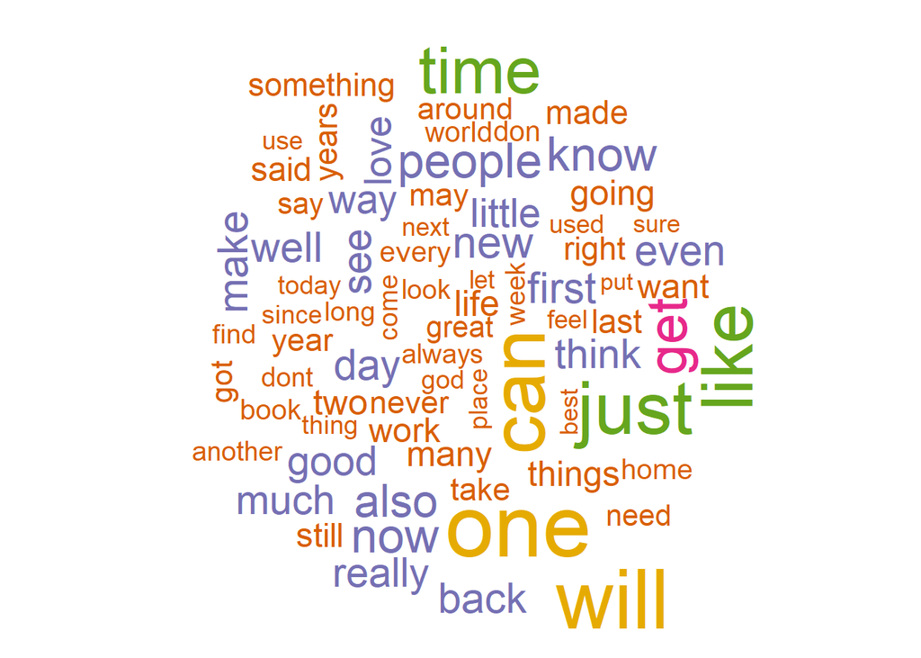

```r
# creating a data frame to display a 'word-cloud' with first 100 most frequent word
blog.dfram <- data.frame(words=names(word_frequency), frequency=word_frequency)
wordcloud(blog.dfram$words, blog.dfram$frequency, scale=c(4,0.5),  min.freq = 4, max.words = 75, random.order=TRUE, rot.per=.15, use.r.layout=FALSE, colors=brewer.pal(6, "Dark2"), ordered.colors = FALSE)
```

```r
#------------------------BI-Gram----------------------------------------------
# Creating a 'BiGram' with a frequency visual to compare with most widely used words
bigram <- NGramTokenizer(corpus2, Weka_control(min=2, max=2))
bigram <- data.frame(table(bigram))
bigram <- bigram[order(bigram$Freq, decreasing = TRUE),]
head(bigram, 10)
```

```
##              bigram Freq
## 1424971   years ago  550
## 1059766   right now  475
## 847833     new york  464
## 415174  even though  462
## 471494   first time  453
## 454362    feel like  422
## 692434    last year  411
## 692400    last week  383
## 760859    make sure  368
## 195223      can see  364
```

**Findings:** We can see from most ‘frequenting-words’ output are in present tense ‘verb-noun’ format portrays discussion with informal conversational style. In addition, we see a pattern of contiguous interconnected words from ‘bi-gram’ output, where each words(token) are related to the preceding one in simple logical way. Each ‘bi-gram’ portrays condtional interdependency between tokens.

## 3. News files: Word frequency, Trigram and Bar graph

News files are essentially written for broad range of audience with indepth analysis infused into it. It is assumed news readers prefer detail connotation of any news topics or subject matter.

**News file summary:**

*Here I’ve decided not to display all the similar codes for computing most frequent ‘words’ and ‘word-trigrams’.*

```
##     File size >  Total Lines >   Words Total
## 1      196.2775          77259       2693898
```

**Most fruequently used 10 words:**

```
##  said  will   one   new   can  year  also first   two  just
##  4758  2020  1571  1361  1162  1148  1117  1087  1058   996
```

**Tri-gram tokenized words with frequency:**

```
##                       trigram Freq
## 341047          two years ago   27
## 247123 president barack obama   21
## 116342       first time since   18
## 212554          new york city   18
## 341466                  u u u   17
## 134046     gov chris christie   16
## 344333      us district court   14
## 360050        will take place   14
## 231182         past two years   13
## 306414        st louis county   13
```

**Barplot with Tri-gram:**

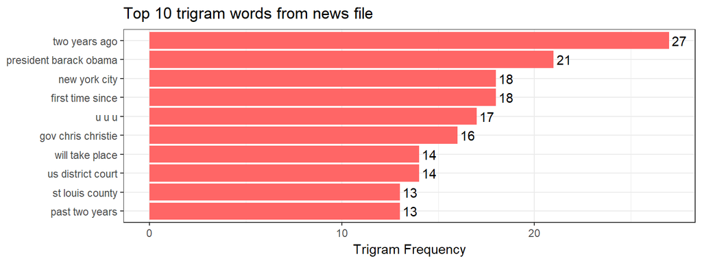

```r
# separating 10-trigram combination for 'bar' display
trigram.Small <- head(trigram, 10)

# plotting trigram with frequency on top bar
newsTrigram <- ggplot(trigram.Small, aes(x=reorder(trigram, Freq), y=Freq)) +  geom_bar(stat="identity", fill="#FF6666") + geom_text(aes(label=Freq), hjust = -0.2)  + theme_bw() + coord_flip() + theme(axis.title.y = element_blank())+labs(y="Trigram Frequency", title="Top 10 trigram words from news file")

print(newsTrigram)
```

**Stopping parallel processing**

**Findings:** On news-file I have decided to analyze ‘tri-gram’, which is contiguous word sequence for probabilistic language model predicts ‘next-word-item’. This tri-gram(head) output from news file will help us to predict next possible continuation of user word choice, thereby help us to write the shiny app.

## Next steps towards a prediction model:

1. Building a simple model based on the most frequent word selections and N-grams output.
2. On that progression of model building, we might need to explore few more detail
   1. Possible model-efficient data cleaning
   2. Data sampling for reduced Runtime
   3. Exploring prebuilt R algorithm like one based on ‘Hidden Markov Chains’ model
3. Creating a shiny App, where users would be allowed to input ‘choice-text’ in a text-box.
4. In a contiguous text-box possible suggested matching text would be displayed to the user.